# Reporte Exploratorio: train_hogares

### Basic Statistics

#### Raw Counts

| Name | Value |
| --- | --- |
| Rows | 164,959 |
| Columns | 13 |
| Discrete columns | 1 |
| Continuous columns | 12 |
| All missing columns | 0 |
| Missing observations | 0 |
| Complete Rows | 164,959 |
| Total observations | 2,144,467 |
| Memory allocation | 15.7 Mb |

#### Percentages

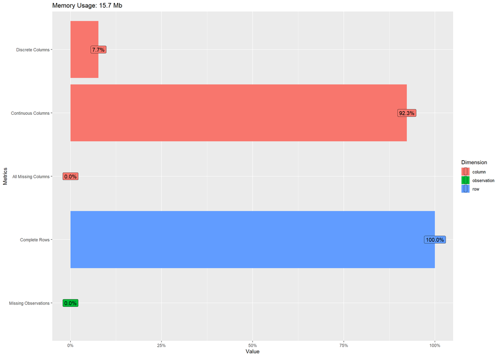

### Data Structure

[interactive chart not shown]

### Missing Data Profile

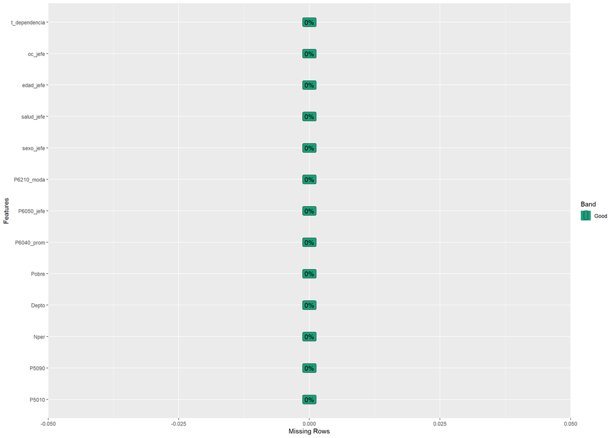

### Univariate Distribution

#### Histogram

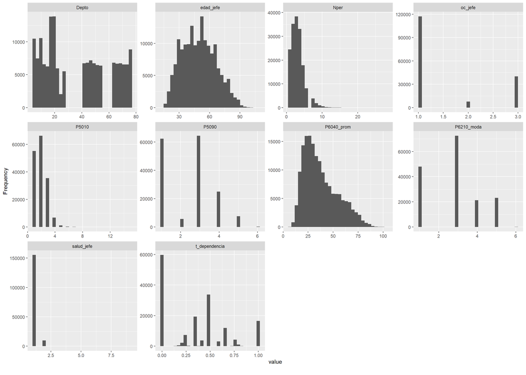

#### Bar Chart (with frequency)

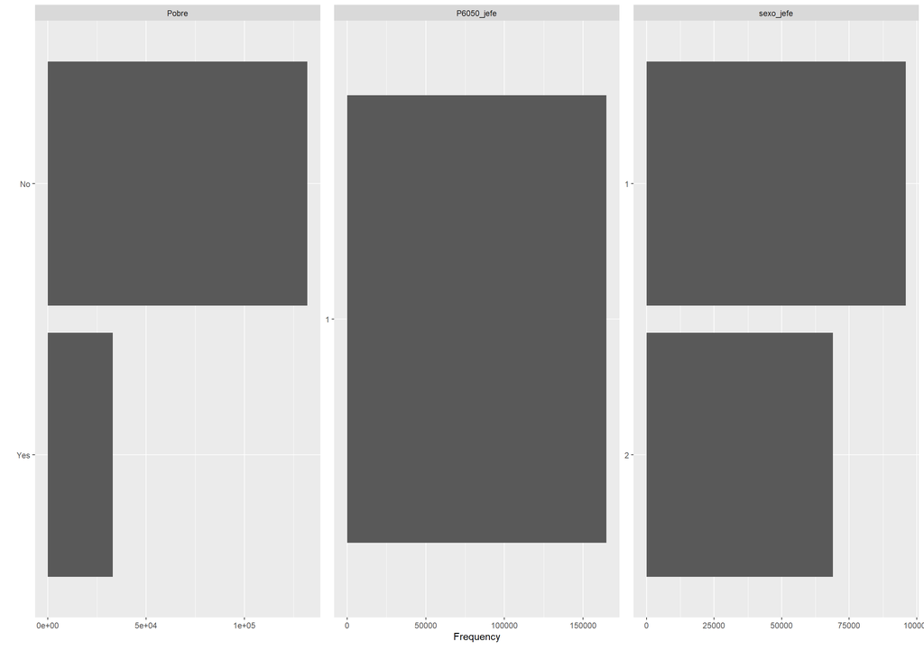